# IE 582 - Homework - 3

Serhat Arca

November 19, 2018

## Task 1.a

Liu et al. (2009) uses a single three-axis accelerometer to collect data from eight users to characterize eight gesture patterns. In this part of the task, we are asked to visualize one instance (all axes) from each class and try to relate the shape (time series) we see with the gestures shown in Figure 1.

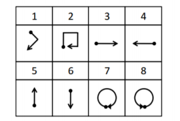

Figure 1 - 8 Gestures from the work by Liu et. al.

The 3d plot obtained by making use of the time ordered observations in the corresponding axis is given in Figure 2:

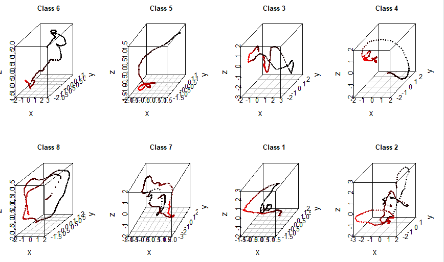

Figure 2 - plot obtained by making use of the time ordered observations.

A comparison of Figure 1 and 2 reveals that, some similarities are present between the two figures, the most obvious being for Class 7 and 8 for their circular shapes.

### Task 1.b

In this part of the task, we are asked to apply nearest-neighbor (NN) classifier to find the labels of test instances based on acceleration information. In order to achieve this, the training data is used to identify the optimal value of k which minimizes the error of a 10-fold cross-validation. The results for Euclidean distance are given in the table below:

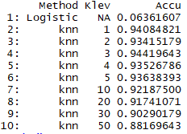

Table 1 - The results for 10-fold cross-validation for Euclidean distance.

An investigation of Table 1 reveals that the highest accuracy is achieved for k=3.This means that the optimal value in Euclidean distance for k is 3, which is used in Part C of this question.

### Task 1.c

In this part of the task, we are asked to use the value of optimal k value from part (b) to evaluate the final performance on the test data. The k-NN is carried out using knn command in R. The result for k=3 using Euclidean distance as an 8-by-8 confusion matrix is given in Table 2:

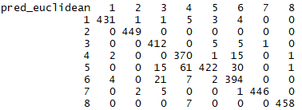

Table 2 - The 8-by-8 confusion matrix for k=3 using Euclidean distance.

The high values in the diagonal of the confusion matrix indicate that the 3-NN is succesful in predicting the labels of the test data. The accuracy is calculated by dividing the sum of diagonals to the total number of test data. The accuracy of the results is 94.4% and the runtime is found as 42.91 sec using tic-toc package.

A similar study is carried out for Manhattan distance measure. The kknn command is used to achieve this. The 8-by-8 confusion matrix for Manhattan distance is given in Table 3:

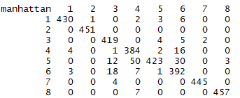

Table 3 - The 8-by-8 confusion matrix for k=3 using Manhattan distance.